# What's on your mind?

### - An Exploratory Analysis of Philosophical Texts

This analysis involves the "Philosophy Dataset" that can be found [here](https://www.kaggle.com/kouroshalizadeh/history-of-philosophy). The dataset contains an compilation of sentences written by famous philosophers in their texts. Though philosophy is a broad subject spanning many topics, I want to see if there are any patterns or commanlities that can be derived across philosophers, their ideas, and also if these ideas/opinions expressed in the text have changed over time. Do certain philosophers think more similarly to others? Will the sentiments of philosophers in their text fall into groups based on schools of thought? What topics are they mostly concerned with and how have their attitudes changed over time?

## Table of Contents:

- Exploring Common Words and Phrases
- Topic Modelling
- Comparing Authors Using Topics and Sentiment
- Changing Sentiments Over Time
- Conclusion

```python
#!{sys.executable} -m pip install wordcloud
#!{sys.executable} -m pip install nltk
#!{sys.executable} -m pip install ipynb

#!{sys.executable} -m pip install -U spacy
#!{sys.executable} -m spacy download de_core_news_sm
#!{sys.executable} -m spacy download en_core_web_lg
#!{sys.executable} -m spacy download en_core_web_sm
#!{sys.executable} -m pip install NRCLex

import sys
import pandas as pd
import numpy as np
import matplotlib.pyplot as plt
import nltk
import gensim
import gensim.corpora as corpora
import nrclex

from nltk.probability import FreqDist
from wordcloud import WordCloud
from nltk.sentiment import SentimentIntensityAnalyzer
from gensim.utils import simple_preprocess
from nltk.corpus import stopwords
from pprint import pprint
from nltk import word_tokenize
from IPython.display import Image
from nrclex import NRCLex
from matplotlib.pyplot import figure
from IPython import display

nltk.download('stopwords')
nltk.download('punkt')
nltk.download(["vader_lexicon"])
nltk.download('averaged_perceptron_tagger')
```

```python
#load the data
df = pd.read_csv("../data/philosophy_data.csv")

#inspect the data
df.head(10)

#from tokenized text string, create an array version (array of strings)
df['tokenized_txt_array'] = df['tokenized_txt'].map(lambda x: x.lstrip('[').rstrip(']').replace("'", "").replace(",", "").split(" "))
```

## 1. Exploring Common Words and Phrases:

### Find the Most Commonly Used Words Across All Texts

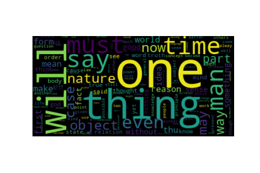

```python
""" Code to generate the word cloud (DON'T RUN)

#create one large array, combining all texts
tmp = df['tokenized_txt_array'].to_numpy()
arr_of_all_texts = np.concatenate(tmp, axis=0)

#create a frequency distribution using the combined text
fdist = FreqDist(arr_of_all_texts)

#create a word, frequency dataframe (collective texts)
df_fdist = pd.DataFrame.from_dict(fdist, orient='index')
df_fdist.columns = ['Frequency']
df_fdist.index.name = 'word'
df_fdist.sort_values(by=['Frequency'], inplace=True, ascending=False)

#create our word cloud
string_of_all_texts = " ".join(arr_of_all_texts)
wordcloud = WordCloud().generate(string_of_all_texts)
plt.imshow(wordcloud, interpolation='bilinear')
plt.axis("off")
plt.savefig('../figs/all_text_word_cloud.png')
plt.show()

#export the most important words as a csv for manual checking for words to do with world vs. humans
df_fdist_copy = df_fdist.copy()
df_fdist_copy.reset_index(inplace=True)
df_fdist_copy.to_csv('../output/word_frequencies.csv')

"""

#display the pre-loaded word-cloud
display.Image("../figs/all_text_word_cloud.png")
```

As we can see there are many interesting insights. Common sentence words such as "will", "one", "saw", "thing", and "must" are frequently used. In terms of topics, a lot of topics that arise involve "man", "nature", "time", "world", and "object" for instance, which is what I would have intuitively thought philosophers would be talking about!

### Find the Most Commonly Used Words By Author

Do certain authors write about the same things as others? Or do they have a particular area of interest?

Let's find out!

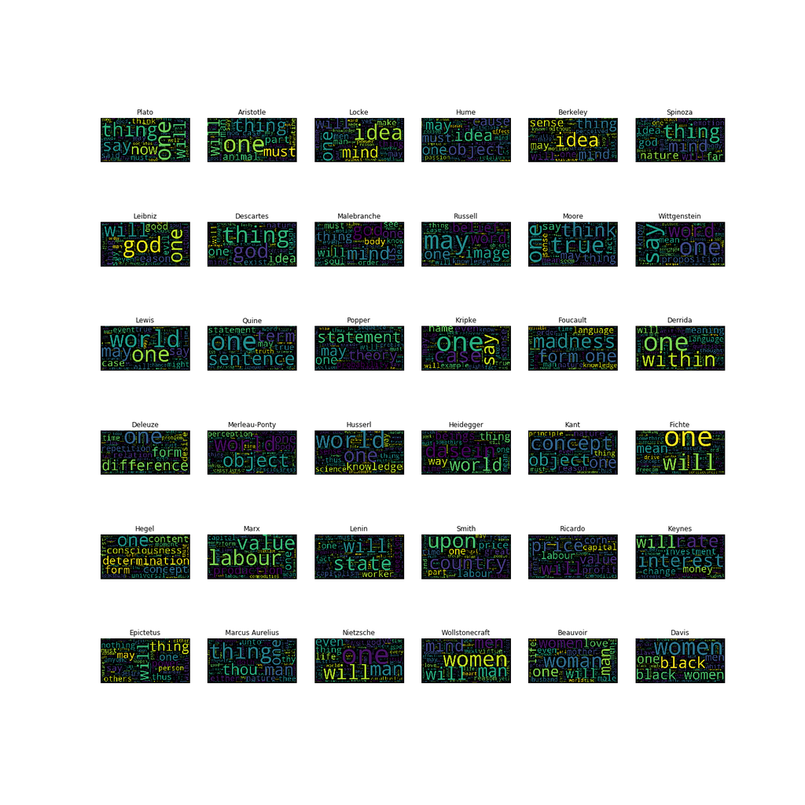

```python
""" Code to generate and save the word cloud for each author (DON'T RUN)

#create a list of unique authors
unique_authors = df.author.unique()

#create a dictionary to store each authors dataframe
authors_dataframe_dictionary = {author : pd.DataFrame for author in unique_authors}

#create the dataframes and assign them to their author
for key in authors_dataframe_dictionary.keys():
    authors_dataframe_dictionary[key] = df[:][df.author == key]

authors_text_dictionary = {author : str for author in unique_authors}

#create a table to store each author and their collective text string
for key in authors_dataframe_dictionary.keys():
    author_name = key
    author_df = authors_dataframe_dictionary[key]
    tmp = author_df['tokenized_txt_array'].to_numpy()
    arr_of_all_texts = np.concatenate(tmp, axis=0)
    string_of_all_texts = " ".join(arr_of_all_texts)
    authors_text_dictionary[author_name] = string_of_all_texts

fig = plt.figure()
fig.set_size_inches(20, 20)

for i in range(len(authors_text_dictionary.keys())):
    ax = fig.add_subplot(6,6,i+1)
    author = list(authors_text_dictionary)[i]
    ax.title.set_text(author)
    string_of_all_texts = authors_text_dictionary[author]
    wordcloud = WordCloud().generate(string_of_all_texts)
    ax.imshow(wordcloud)
    ax.axis('off')

plt.savefig('../figs/word_cloud_by_author')
plt.show()

"""

#display the pre-loaded word-cloud for each author
display.Image("../figs/word_cloud_by_author.png")
```

As we can see certain patterns seem to emerge and we can start to see groups forming based on their topics of itnerest. Notably, in the second row we see authors such as Leibniz, Descartes, and Malebranche referecing "God" a lot. Others such Hume, Berkeley, and Spinoza seem to be have a lot of text regarding "Ideas". Other notable observations include Marx and Lenin who focus on labour, production, the state, etc. which makes sense in their contexts as political figures rather than philosophers. Similarly, Smith, Ricardo, and Keynes also make reference to government but seem to be interested in the idea of labour, capital, and economy. Finally Wollstoncraft, Beauvoir and Davis can be grouped as talking a lot about women which makes sense as women's rights activists.

### Finding the Most Commonly Used Tri-Grams

This investigation of the data can be extended into finding most common pairings of words, as this may give us more insight into common thoughts expressed in the text rather than isolated words. Looking into N-Grams (ordered strings of N words) may serve beneficial in exploring common themes.

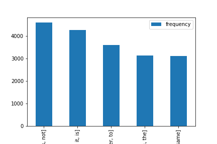

```python
"""Code to generate and save the bar plot for most used Tri-Grams (DON'T RUN)

#create a list of tokenized text (collective) with * indicating separate sentences (to remove from n-gram consideration)
tmp = df['tokenized_txt_array'].to_numpy()
tmp_space = []

for i in range(len(tmp)):
    tmp_space.append(list('*'))

#create the list
tmp_text = np.array([[i, j] for i, j in zip(tmp, tmp_space)]).ravel()
tmp_arr_of_all_texts = np.concatenate(tmp_text, axis=0)

#build a ngram finder on top of the list using nltk
finder = nltk.collocations.TrigramCollocationFinder.from_words(tmp_arr_of_all_texts)
finder.ngram_fd.most_common(10)

#VISUALIZATION:
top_ngrams = []
i = 0
j = 1

#only the most common 5 tri-grams that don't contain a spacer '*'
while(i < 5):
    n_gram_list = list(finder.ngram_fd.most_common(j)[-1][0])
    n_gram_count = finder.ngram_fd.most_common(j)[-1][1]

    if ('*' in n_gram_list):
        j += 1
        continue

    elif('*' not in n_gram_list):
        top_ngrams.append([n_gram_list, n_gram_count])
        i += 1
        j += 1

n_grams_df = pd.DataFrame(top_ngrams, columns =['tri_gram', 'frequency'])
fig = n_grams_df.plot.bar(x='tri_gram', y="frequency")
fig.get_figure().savefig('../figs/common_tri-grams.png')

"""

#display the pre-loaded word-cloud for each author
display.Image("../figs/common_tri-grams.png")
```

Not much insight can be derived from this chart. Here, we see that a lot of the most common tri-grams in the text are normal sentence phrases. Based on the results, the top 5 tri-grams are:

1. "It is not"
2. "That it is"
3. "In order to"
4. "It is the"
5. "At the same"

Notably the 3rd most common tri-gram is interesting because a call to action is likely to follow from the phrase "in order to", which might indicate that anticipation or urgency might be a common emotion felt in a lot of these texts. It also indicates that a lot of the texts were written with a specific purpose, to urge something or convey a point.

### Finding the Most Common Nouns

In trying to find common themes, often we run into words that are merely common in sentences (such as I, verbs, etc.). Because of this, by just looking at the most common words/set of words, this might not be enough to see topics. Using the NLTK library, we can leverage POS tagging to filter out so we are left with just the most common nouns rather than words. The code is hidden below, and due to this being very time costly, a previously computed table can be imported.

```python
""" Code to Find Frequency Distribution of Nouns in the Text (DON'T RUN)

nouns = []

for index, row in df_fdist_copy.iterrows():
    if(len(str(row['word'])) > 0):
        ans = nltk.pos_tag(word_tokenize(str(row['word'])))
        val = ans[0][1]
        if(val == 'NN' or val == 'NNS' or val == 'NNPS' or val == 'NNP'):
            nouns.append(str(row['word']))
        else:
            df_fdist_copy.drop([index], inplace=True)

df_fdist_copy.to_csv('../output/noun_frequencies.csv')

"""

noun_fdist = pd.read_csv('../output/noun_frequencies.csv')
noun_fdist[['word','Frequency']].head(10)
```

|  | word | Frequency |
| --- | --- | --- |
| 0 | things | 17482 |
| 1 | man | 16152 |
| 2 | time | 15307 |
| 3 | way | 12854 |
| 4 | nature | 12796 |
| 5 | world | 12088 |
| 6 | reason | 11464 |
| 7 | thing | 11275 |
| 8 | something | 10841 |
| 9 | part | 9838 |

(Above) The 10 most common nouns that appear in the text. There seem to be two main topics: Humans and the World (anthropocentric vs. ecocentric ideas). This idea will be used later when we assess the similarity of the expression of authors.

## 2. Topic Modelling:

Looking deeper into the topics of interest, I will try to apply the LDA Topic Model learned in class to see if there are any reoccuring themes in the collective texts.

```python
stop_words = stopwords.words('english')
stop_words.extend(['from', 'subject', 're', 'edu', 'use'])

def sent_to_words(sentences):
    for sentence in sentences:
        # deacc=True removes punctuations
        yield(gensim.utils.simple_preprocess(str(sentence), deacc=True))

def remove_stopwords(texts):
    return [[word for word in simple_preprocess(str(doc))
             if word not in stop_words] for doc in texts]

df['text_processed'] = df['tokenized_txt'].map(lambda x: x.lstrip('[').rstrip(']').replace("'", "").replace(",", ""))

data = df.text_processed.values.tolist()
data_words = list(sent_to_words(data))
data_words = remove_stopwords(data_words)

# Create Dictionary
id2word = corpora.Dictionary(data_words)
# Create Corpus
texts = data_words
# Term Document Frequency
corpus = [id2word.doc2bow(text) for text in texts]
# View

# number of topics
num_topics = 5

# Build LDA model
lda_model = gensim.models.LdaMulticore(corpus=corpus,
                                       id2word=id2word,
                                       num_topics=num_topics)

# Print the Keyword in the  topics
pprint(lda_model.print_topics())
doc_lda = lda_model[corpus]
```

```
[(0,
  '0.011*"one" + 0.007*"first" + 0.005*"two" + 0.005*"us" + 0.004*"must" + '
  '0.004*"also" + 0.004*"way" + 0.004*"like" + 0.003*"time" + 0.003*"another"'),
 (1,
  '0.015*"one" + 0.010*"must" + 0.008*"time" + 0.006*"two" + 0.006*"first" + '
  '0.006*"consciousness" + 0.005*"world" + 0.005*"therefore" + 0.005*"part" + '
  '0.004*"nature"'),
 (2,
  '0.008*"would" + 0.008*"one" + 0.006*"labour" + 0.006*"also" + 0.005*"value" '
  '+ 0.005*"upon" + 0.004*"price" + 0.004*"thus" + 0.004*"great" + '
  '0.004*"women"'),
 (3,
  '0.012*"one" + 0.009*"concept" + 0.007*"world" + 0.006*"would" + '
  '0.006*"even" + 0.005*"something" + 0.005*"knowledge" + 0.004*"capital" + '
  '0.004*"nothing" + 0.004*"may"'),
 (4,
  '0.010*"would" + 0.007*"one" + 0.006*"good" + 0.006*"things" + 0.005*"know" '
  '+ 0.005*"nature" + 0.005*"may" + 0.005*"man" + 0.005*"thing" + '
  '0.005*"even"')]
```

When 5 categories are assigned to the model, the LDA results in the above, where the coefficient of each word corresponds to its importance/magnitude to the topic. Though not all of them are clear cut, if I had to assign each topic a label it would be something like:

1. Action/Urgency
2. The Mind
3. Women Workforce, Labour, Economy
4. Knowledge
5. Character

These are all very rough guesses and displays one of the downfalls of LDA. Perhaps experimenting with more/less topics may help narrow down on more solid topics/themes but it is too costly to perform in this exploration.

Perhaps applying LDA on just nouns may provide more interesting results ...

```python
""" Code to Add Nouns Array for Each Sentence (DON'T RUN)

def filter_nouns(row):

    tmp_nouns = []

    for word in row['tokenized_txt_array']:
        if(len(word) != 0):
            ans = nltk.pos_tag(word_tokenize(word))
            val = ans[0][1]
            if(val == 'NN' or val == 'NNS' or val == 'NNPS' or val == 'NNP'):
                tmp_nouns.append(word)

    nouns_str = " ".join(tmp_nouns)

    return nouns_str

df['tokenized_nouns_array'] = df.apply(lambda row: filter_nouns(row), axis=1)
df.to_csv('df_with_nouns_array.csv')

df_with_nouns = df.copy()

df_with_nouns = df_with_nouns.fillna(0)

df_with_nouns = df_with_nouns['tokenized_nouns_array'].values.tolist()

df_with_nouns = pd.DataFrame(df_with_nouns)
df_with_nouns.to_csv('../output/df_with_nouns_list.csv')

"""

#load the pre-loaded
df_with_nouns_list = pd.read_csv('../output/df_with_nouns_list')
```

```python
#https://towardsdatascience.com/end-to-end-topic-modeling-in-python-latent-dirichlet-allocation-lda-35ce4ed6b3e0

df_with_nouns_list = pd.read_csv('../output/df_with_nouns_list.csv')

stop_words = stopwords.words('english')
stop_words.extend(['from', 'subject', 're', 'edu', 'use'])

def sent_to_words(sentences):
    for sentence in sentences:
        # deacc=True removes punctuations
        yield(gensim.utils.simple_preprocess(str(sentence), deacc=True))

def remove_stopwords(texts):
    return [[word for word in simple_preprocess(str(doc))
             if word not in stop_words] for doc in texts]

data = df_with_nouns_list['0'].values.tolist()
data_words = list(sent_to_words(data))
data_words = remove_stopwords(data_words)

# Create Dictionary
id2word = corpora.Dictionary(data_words)
# Create Corpus
texts = data_words
# Term Document Frequency
corpus = [id2word.doc2bow(text) for text in texts]
# View

# number of topics
num_topics = 5
# Build LDA model
lda_model = gensim.models.LdaMulticore(corpus=corpus,
                                       id2word=id2word,
                                       num_topics=num_topics)

# Print the Keyword in the 10 topics
pprint(lda_model.print_topics())
doc_lda = lda_model[corpus]
```

```
[(0,
  '0.007*"object" + 0.007*"labour" + 0.006*"things" + 0.006*"movement" + '
  '0.006*"meaning" + 0.006*"means" + 0.005*"space" + 0.005*"difference" + '
  '0.005*"place" + 0.005*"power"'),
 (1,
  '0.016*"thing" + 0.014*"consciousness" + 0.014*"concept" + 0.013*"something" '
  '+ 0.009*"man" + 0.007*"way" + 0.006*"reason" + 0.006*"nature" + '
  '0.006*"work" + 0.005*"capital"'),
 (2,
  '0.022*"world" + 0.007*"determination" + 0.006*"state" + 0.006*"existence" + '
  '0.006*"means" + 0.006*"self" + 0.006*"science" + 0.006*"body" + 0.005*"way" '
  '+ 0.005*"truth"'),
 (3,
  '0.009*"women" + 0.009*"man" + 0.008*"time" + 0.007*"things" + 0.007*"men" + '
  '0.007*"fact" + 0.006*"part" + 0.006*"woman" + 0.005*"love" + 0.005*"self"'),
 (4,
  '0.008*"time" + 0.008*"nature" + 0.008*"value" + 0.008*"form" + 0.007*"case" '
  '+ 0.007*"sense" + 0.006*"thou" + 0.005*"quantity" + 0.005*"theory" + '
  '0.005*"things"')]
```

Using just nouns seems to narrow the topics down a little bit (getting rid of filler words such as also and like). There is some notion of the relationship between men and women (maybe concerning humans in general) in topic 3 which may have to do with the publications dealing with women's rights. Also, there is some focus on science and understanding the world in topic 2, though these topics are still not as clear cut.

## 3. Comparing Authors Using Topics and Sentiment

Based on the exploratory analysis and the results of topic modelling (sections 1 and 2 respectively), it seems that we can class the thoughts expressed in the text in many ways. One of the ways is World vs. Human, where the Human side focuses more on the issues regarding man, and the World side focuses more on the environment, the universe, and so on. Another possible way is to think of people as individuals or as a collective unit, for instance, talking about a person as compared to a society or state. Using these topics, we can plot their topic focus, as well as their sentiment (positive or negative) regarding these topics on a 2D plane to categorize them into 4 major quadrants, and hopefully identify similar thinking authors.

```python
def human_world(row):

    human = 0
    world = 0

    human_words = ['Man', 'Men', 'People', 'Person', 'Human', 'Woman', 'Women',
                   'Children', 'Ourselves', 'man', 'men', 'people', 'person',
                   'human', 'woman', 'women', 'children', 'ourselves']

    world_words = ['World', 'Universal', 'Animals', 'Country', 'Earth', 'Land',
                   'Universe', 'Nature', 'world', 'universal', 'animals',
                   'country', 'earth', 'land', 'universe', 'nature']

    sentence = row['tokenized_txt_array']

    for term in human_words:
        human += sentence.count(term)

    for term in world_words:
        world += sentence.count(term)

    total = human + world

    if total == 0:
        return {'human' : 0, 'world' : 0}

    return {'human' : (human/total), 'world' : (world/total)}

def individual_collective(row):

    individual = 0
    collective = 0

    individual_words = ['Man', 'man', 'Woman', 'woman', 'Person', 'person', 'Child', 'child']

    collective_words = ['World', 'People', 'Men', 'Human', 'Women', 'People', 'Earth', 'Country',
                       'Children', 'Society', 'Species', 'Ourselves', 'Government', 'Everyone',
                       'world', 'people', 'men', 'human', 'women', 'people', 'earth', 'country',
                       'children', 'society', 'species', 'ourselves', 'government', 'everyone']

    sentence = row['tokenized_txt_array']

    for term in individual_words:
        individual += sentence.count(term)

    for term in collective_words:
        collective += sentence.count(term)

    total = individual + collective

    if total == 0:
        return {'individual' : 0, 'collective' : 0}

    return {'individual' : (individual/total), 'collective' : (collective/total)}
```

```python
"""Code to calculate the magnitude of different topics for each sentence and their sentiment (DON'T RUN)

#calculate the percent of the sentence to do with human or world
df['human_vs_world'] = df.apply (lambda row: human_world(row), axis=1)
df = pd.concat([df.drop(['human_vs_world'], axis=1), df['human_vs_world'].apply(pd.Series)], axis=1)

#calculate the percent of the sentence to do with individual or collective
df['individual_collective'] = df.apply (lambda row: individual_collective(row), axis=1)
df = pd.concat([df.drop(['individual_collective'], axis=1), df['individual_collective'].apply(pd.Series)], axis=1)

#load our sentiment analyzer
sia = SentimentIntensityAnalyzer()

#function that returns the sentiments for a row
def sia_analysis(row):
    tmp = sia.polarity_scores(row['sentence_lowered'])
    del tmp['compound']
    return tmp

#create columns for pos, neu, and neg sentiments and fill in their values based on the sentence
df['sia_analysis'] = df.apply (lambda row: sia_analysis(row), axis=1)
df = pd.concat([df.drop(['sia_analysis'], axis=1), df['sia_analysis'].apply(pd.Series)], axis=1)

#generate each table

df_with_categories_and_sentiments = df.copy()

df_human_world = df_with_categories_and_sentiments[(df_with_categories_and_sentiments['human'] != 0) | (df_with_categories_and_sentiments['world'] !=0)]
df_human_world = df_human_world[['author', 'human', 'world', 'neg', 'neu', 'pos']].groupby('author').mean()
df_human_world['x_axis'] = df_human_world['human'] - 0.5
df_human_world['y_axis'] = df_human_world['pos'] - df_human_world['neg']
df_human_world.to_csv('../output/df_human_world.csv')

df_individual_collective = df_with_categories_and_sentiments[(df_with_categories_and_sentiments['individual'] != 0) | (df_with_categories_and_sentiments['collective'] !=0)]
df_individual_collective = df_individual_collective[['author', 'individual', 'collective', 'neg', 'neu', 'pos']].groupby('author').mean()
df_individual_collective['x_axis'] = df_individual_collective['collective'] - 0.5
df_individual_collective['y_axis'] = df_individual_collective['pos'] - df_individual_collective['neg']
df_individual_collective.to_csv('../output/df_individual_collective.csv')


"""
```

First we'll take a look at the idea of humans vs. world. We load in the pre-loaded csv to save time.

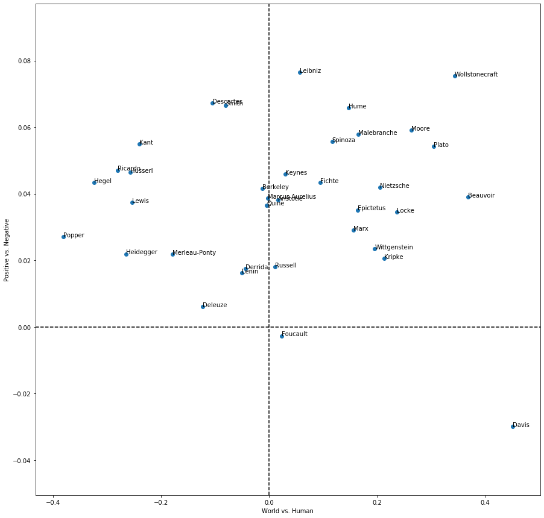

```python
df_human_world = pd.read_csv('../output/df_human_world.csv')

x = df_human_world['x_axis'].values
y = df_human_world['y_axis'].values
z = df_human_world['author'].values

fig = plt.figure()

plt.scatter(x, y)

for i, txt in enumerate(z):
    plt.annotate(txt, (x[i], y[i]))

fig.set_figheight(15)
fig.set_figwidth(15)

plt.axvline(x=0, color='k', linestyle='--')
plt.axhline(y=0, color='k', linestyle='--')
plt.xlabel('World vs. Human')
plt.ylabel('Positive vs. Negative')
fig.savefig('../figs/world_vs_human_sentiment_graph.png')
```

As evident above it seems that most texts have positive sentiments attached to them. This may be because there is a sense of hopefulness with a lot of these texts despite them not always being about positive things. Calling for a better change might be one of the big reasons why a lot of them are positive. In terms of the humans vs. world split, it seems that there are generally an even number of philosphers whose texts deal with humans and the environment around them. There seem to be those who stray further to one of these sides and also a group of those who seem to be cut straight down the middle (which might indicate they didn't talk about either). One potential limitation to this is that the calculation for world vs. human was done using a list of words I manually inspected from the noun_frequency distribution earlier (calculate fraction of each topic in each sentence and average), and many of these words at times may be ambiguous (for instance, nature could refer to the environment or human nature). Since this method only looks into one isolated world at a time rather than a word and its surrounding words this is a limitation.

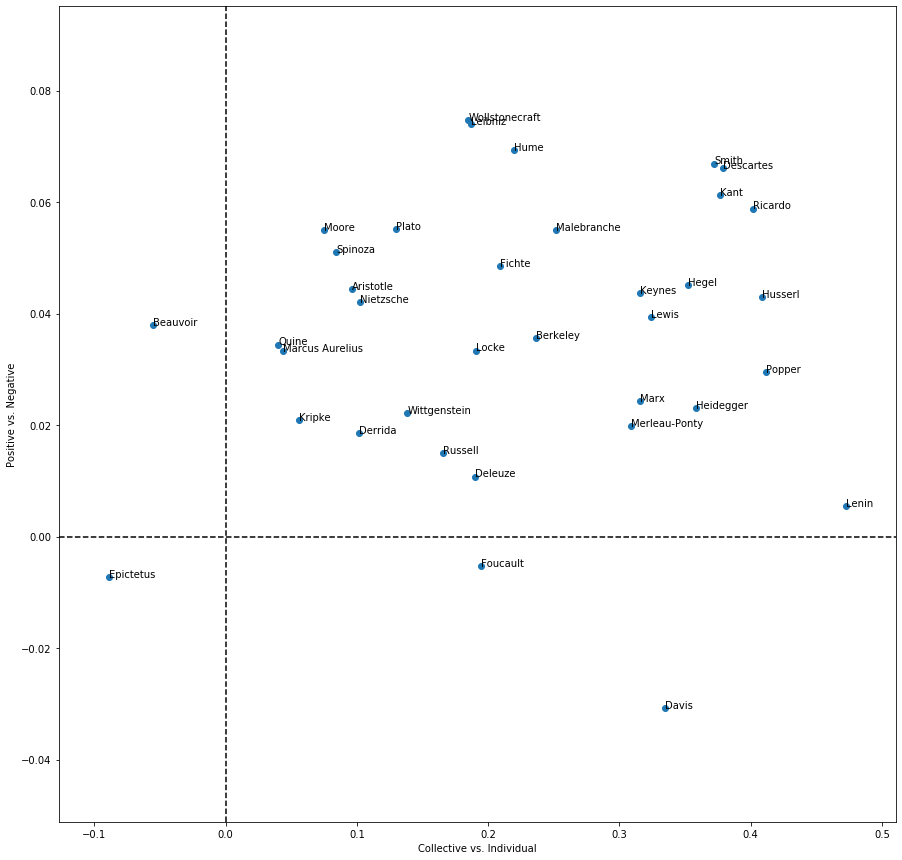

```python
df_individual_collective = pd.read_csv('../output/df_individual_collective.csv')

x = df_individual_collective['x_axis'].values
y = df_individual_collective['y_axis'].values
z = df_individual_collective['author'].values

fig, ax = plt.subplots( )
ax.scatter(x, y)

for i, txt in enumerate(z):
    ax.annotate(txt, (x[i], y[i]))

fig.set_figheight(15)
fig.set_figwidth(15)

plt.axvline(x=0, color='k', linestyle='--')
plt.axhline(y=0, color='k', linestyle='--')
plt.xlabel('Collective vs. Individual')
plt.ylabel('Positive vs. Negative')
fig.savefig('../figs/collective_vs_individual_sentiment_graph.png')
```

```python
"""Code to get the most negative and positive sentences from Davis and Wollstonecraft

#relies on df_with_cateogies_and_sentiments which is too large to upload so must save to output)

davis = df_with_categories_and_sentiments[df_with_categories_and_sentiments['author'] == 'Davis'].sort_values(by=['neg'], ascending=False)['sentence_str'][0:5].values
wollstonecraft = df_with_categories_and_sentiments[df_with_categories_and_sentiments['author'] == 'Davis'].sort_values(by=['pos'], ascending=False)['sentence_str'][0:5].values

davis = pd.DataFrame(davis)
davis.to_csv('../output/davis.csv')

wollstonecraft = pd.DataFrame(wollstonecraft)
wollstonecraft.to_csv('../output/wollstonecraft.csv')

"""
```

```python
davis = pd.read_csv('../output/davis.csv')
wollstonecraft = pd.read_csv('../output/wollstonecraft.csv')

print("Davis:")
for text in davis['0'].values:
    print(text)

print("\nWollstonecraft:")
for text in wollstonecraft['0'].values:
    print(text)
```

```
Davis:
Rape, Racism and the Myth of the Black Rapist
she exclaimed with deliberately racist arrogance.
DuBois observed: It is always difficult to stop war, and doubly difficult to stop civil war.
Viewed as 'loose women' and whores, Black women's cries of rape would necessarily lack legitimacy.
Rape the white girls.

Wollstonecraft:
Because of her family's wealth, she enjoyed unique educational opportunities.
It rose like perfume like a prayer.
We thank him for his many blessings.
Of course, the 'good' servant is always faithful, trustworthy and grateful.
She was one of America's truly great women, fearless, and devoted to the working class.
```

## 4. Changing Sentiments Over Time

Finally, I want to see the general change in attitude or sentiment in these texts over time to see if there are any trends with how philosophers viewed our world (Was it getting better? Worse?). However, there wasn't a large, diverse selection of texts from different time periods, rather sparse and dense, so I decided to bucket them by centuries. However, one clear limitation is that different author's text were going to be correlated to the time period they wrote in (since each author most likely wrote their publications around the same time), therefore strongly negative/positive authors are going to greatly influence the overall sentiment for that century, (since I'm averaging by century). Despite this I do still believe it will be intersting to view.

```python
# find the original publication dates for each author
tmp1 = df[['author', 'original_publication_date']]
tmp1 = tmp1.astype(str).groupby('author').agg(lambda x: ','.join(x.unique()))
tmp1
```

| author | original_publication_date |
| --- | --- |
| Aristotle | -320 |
| Beauvoir | 1949 |
| Berkeley | 1713,1710 |
| Davis | 1981 |
| Deleuze | 1968,1972 |
| Derrida | 1967 |
| Descartes | 1637,1641 |
| Epictetus | 125 |
| Fichte | 1798 |
| Foucault | 1963,1961,1966 |
| Hegel | 1817,1807,1820 |
| Heidegger | 1927,1950 |
| Hume | 1739,1779 |
| Husserl | 1936,1907 |
| Kant | 1788,1790,1781 |
| Keynes | 1936 |
| Kripke | 1972,1975 |
| Leibniz | 1710 |
| Lenin | 1862 |
| Lewis | 1985 |
| Locke | 1689 |
| Malebranche | 1674 |
| Marcus Aurelius | 170 |
| Marx | 1883,1848 |
| Merleau-Ponty | 1945 |
| Moore | 1910 |
| Nietzsche | 1888,1886,1887 |
| Plato | -350 |
| Popper | 1959 |
| Quine | 1950 |
| Ricardo | 1817 |
| Russell | 1921,1912 |
| Smith | 1776 |
| Spinoza | 1677 |
| Wittgenstein | 1953,1921,1950 |
| Wollstonecraft | 1792 |

```python
"""Code to set up the table with each of the NRC emotion indicators (DON'T RUN)

def tokenized_txt_string(row):
    arr = row['tokenized_txt_array']
    return " ".join(arr)

df['tokenized_txt_string'] = df.apply(lambda row: tokenized_txt_string(row), axis=1)

def emotion(row):
    text_object = NRCLex(row['tokenized_txt_string'])
    return text_object.raw_emotion_scores

df['NRC emotion'] = df.apply (lambda row: emotion(row), axis=1)
df = pd.concat([df.drop(['NRC emotion'], axis=1), df['NRC emotion'].apply(pd.Series)], axis=1)
df.to_csv('df_with_emotions.csv')

emotions_df = df[['original_publication_date', 'negative', 'sadness',
       'surprise', 'positive', 'trust', 'anticipation', 'anger', 'fear',
       'disgust', 'joy']].fillna(0)

emotions_df = emotions_df.groupby('original_publication_date').mean()

emotions_df.to_csv('../output/emotions_df.csv')

"""

emotions_df = pd.read_csv('../output/emotions_df.csv')
```

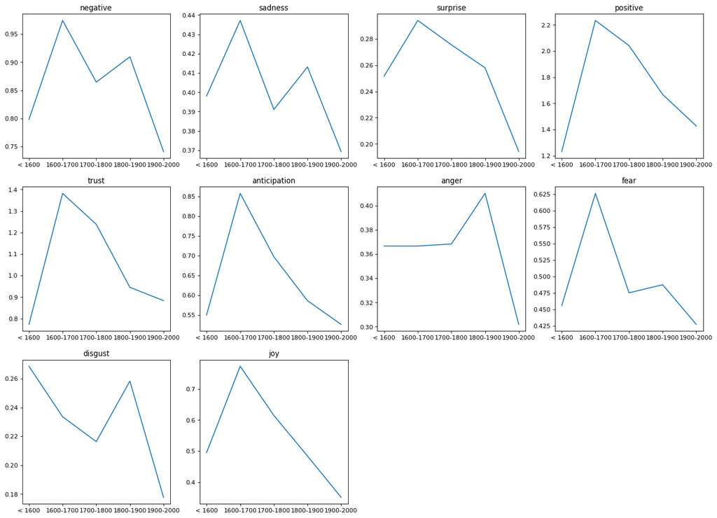

```python
def bucket_dates(row):
    if(row['original_publication_date'] < 1600):
        return '< 1600'

    elif(row['original_publication_date'] < 1700):
        return '1600-1700'

    elif(row['original_publication_date'] < 1800):
        return '1700-1800'

    elif(row['original_publication_date'] < 1900):
        return '1800-1900'

    elif(row['original_publication_date'] < 2000):
        return '1900-2000'

emotions_df['date bucket'] = emotions_df.apply(lambda row: bucket_dates(row), axis=1)

tmp = emotions_df.groupby('date bucket').mean()[['negative', 'sadness',
       'surprise', 'positive', 'trust', 'anticipation', 'anger', 'fear',
       'disgust', 'joy']]

date = list(tmp.index.values)
date.insert(0, date.pop())

negative = list(tmp['negative'].values)
negative.insert(0, negative.pop())

sadness = list(tmp['sadness'].values)
sadness.insert(0, sadness.pop())

surprise = list(tmp['surprise'].values)
surprise.insert(0, surprise.pop())

positive = list(tmp['positive'].values)
positive.insert(0, positive.pop())

trust = list(tmp['trust'].values)
trust.insert(0, trust.pop())

anticipation = list(tmp['anticipation'].values)
anticipation.insert(0, anticipation.pop())

anger = list(tmp['anger'].values)
anger.insert(0, anger.pop())

fear = list(tmp['fear'].values)
fear.insert(0, fear.pop())

disgust = list(tmp['disgust'].values)
disgust.insert(0, disgust.pop())

joy = list(tmp['joy'].values)
joy.insert(0, joy.pop())

figure(figsize=(20, 20), dpi=80)

emotion_vars = [negative, sadness,
       surprise, positive, trust, anticipation, anger, fear,
       disgust, joy]

emotions = ['negative', 'sadness',
       'surprise', 'positive', 'trust', 'anticipation', 'anger', 'fear',
       'disgust', 'joy']

for i in range(len(emotions)):

    plt.subplot(4, 4, i+1)
    plt.plot(date, emotion_vars[i])
    plt.title(emotions[i])

plt.savefig('../figs/sentiments_over_time.png')
plt.show()
```

Based on the results above there seems to be no clear general trend for any emotion, though most positive emotions seem to be consistently going down more recently. One of the limitations here is that there are also very few points coming from relatively few sources giving the wide time-period intervals. Negative emotions such as negative, sadness, anger, and fear seem to be more unpredictable, and may be related to specific moments in history this would suggest.

## 5. Conlusion

Going back to the original question: 'What's on your mind?', based on the results of word-clouding and LDA it seems that the philosophers in this data set can be clustered into specific groups based on their interests and the things they tend to talk about. Authors such as Davis, Beauvoir, and Wollstonecraft tend to focus on issues regarding women's rights. Others like Marx, Lenin, and Smith focus on government, labour, and the workforce as topics of interest. Ricardo and Keynes tend to write about economics. More of the earlier philosophers such as Plato, Aristotle and Locke focus more on traditional topics like human nature, thought, the mind, etc.

Finally, the overall sentiment from these sources based on time period seem to vary. For positive emotions such as joy, trust, and surprise, they seem to be decreasing as we go from older texts to more recent ones. Negative emotions such as anger and sadness seem to be very variable, jumping up and down based on the time period, which may be an indication that certain times might have negative current events some philosophers cover.

There are a couple of limitations to this analysis. Mainly the fact that a lot of the natural language analysis that I personally coded looks at singular words, ignoring the words around them. Also the list of words it is looking for for each topic was human-selected, which may not always be a good indicator of the topic we are trying to identify. Also, the groups of sentiments over time are naturally going to vary based on which philosophers were around during that time period producing text, so it may be a reflection more of the philosopher than the time period. Other more specific limitations are made not of in earlier cells.